# Practical Machine learning Project

Ryan Einbender

April 29, 2016

# Introdution

Using devices such as Jawbone Up, Nike FuelBand, and Fitbit it is now possible to collect a large amount of data about personal activity relatively inexpensively. These type of devices are part of the quantified self movement - a group of enthusiasts who take measurements about themselves regularly to improve their health, to find patterns in their behavior, or because they are tech geeks. One thing that people regularly do is quantify how much of a particular activity they do, but they rarely quantify how well they do it. In this project, your goal will be to use data from accelerometers on the belt, forearm, arm, and dumbell of 6 participants. They were asked to perform barbell lifts correctly and incorrectly in 5 different ways. More information is available from the website here: http://groupware.les.inf.puc-rio.br/har (see the section on the Weight Lifting Exercise Dataset).

# Data Used

The training data for this project are available here: https://d396qusza40orc.cloudfront.net/predmachlearn/pml-training.csv

The test data are available here: https://d396qusza40orc.cloudfront.net/predmachlearn/pml-testing.csv

The data for this project come from this source: http://groupware.les.inf.puc-rio.br/har. If you use the document you create for this class for any purpose please cite them as they have been very generous in allowing their data to be used for this kind of assignment.

# Goal

The goal of your project is to predict the manner in which they did the exercise. This is the “classe” variable in the training set. You may use any of the other variables to predict with. You should create a report describing how you built your model, how you used cross validation, what you think the expected out of sample error is, and why you made the choices you did. You will also use your prediction model to predict 20 different test cases.

# Obtaining the Data

```r
set.seed(12543)
library(caret)
```

```r
library(rpart)
library(rpart.plot)
library(RColorBrewer)
library(rattle)
library(randomForest)
library(knitr)

trainUrl <- "http://d396qusza40orc.cloudfront.net/predmachlearn/pml-training.csv"
testUrl <- "http://d396qusza40orc.cloudfront.net/predmachlearn/pml-testing.csv"

training <- read.csv(url(trainUrl), na.strings=c("NA","#DIV/0!",""))
testing <- read.csv(url(testUrl), na.strings=c("NA","#DIV/0!",""))
```

Now lets break this data set into 2 groups (training and testing)

```r
inTrain <- createDataPartition(training$classe, p=0.6, list=FALSE)
myTraining <- training[inTrain, ]
myTesting <- training[-inTrain, ]
dim(myTraining); dim(myTesting)
```

```
## [1] 11776   160
```

```
## [1] 7846  160
```

# Data Cleansing

this step we will remove NearZeroVariance variables

```r
nzv <- nearZeroVar(myTraining, saveMetrics=TRUE)
myTraining <- myTraining[,nzv$nzv==FALSE]

nzv<- nearZeroVar(myTesting,saveMetrics=TRUE)
myTesting <- myTesting[,nzv$nzv==FALSE]
```

```r
myTraining <- myTraining[c(-1)]
training1 <- myTraining
for(i in 1:length(myTraining)) {
    if( sum( is.na( myTraining[, i] ) ) /nrow(myTraining) >= .7) {
        for(j in 1:length(training1)) {
            if( length( grep(names(myTraining[i]), names(training1)[j]) ) == 1)  {
                training1 <- training1[ , -j]
            }
        }
    }
}

# Set back to the original variable name
myTraining <- training1
rm(training1)
```

Next we will remove the classe column

```r
clean1 <- colnames(myTraining)
clean2 <- colnames(myTraining[, -58])  # remove the classe column
myTesting <- myTesting[clean1]
testing <- testing[clean2]

dim(myTesting);
```

```
## [1] 7846   58
```

```r
dim(testing)
```

```
## [1] 20 57
```

reconcile data classes between Training and testing

```r
for (i in 1:length(testing) ) {
    for(j in 1:length(myTraining)) {
        if( length( grep(names(myTraining[i]), names(testing)[j]) ) == 1)  {
            class(testing[j]) <- class(myTraining[i])}}}

testing <- rbind(myTraining[2, -58] , testing)
testing <- testing[-1,]
```

# Decision Trees

[figure not shown]

Next lets look at the accuracy and kappa of our model

```r
predictionsA1 <- predict(modFitA1, myTesting, type = "class")
cmtree <- confusionMatrix(predictionsA1, myTesting$classe)
cmtree
```

```
## Confusion Matrix and Statistics
##
##           Reference
## Prediction    A    B    C    D    E
##          A 2166   63    7    2    0
##          B   45 1268   91   63    0
##          C   21  181 1239  135   46
##          D    0    6   14  884   82
##          E    0    0   17  202 1314
##
## Overall Statistics
##
##                Accuracy : 0.8757
##                  95% CI : (0.8682, 0.883)
##     No Information Rate : 0.2845
##     P-Value [Acc > NIR] : < 2.2e-16
##
##                   Kappa : 0.8427
##  Mcnemar's Test P-Value : NA
##
## Statistics by Class:
##
##                      Class: A Class: B Class: C Class: D Class: E
## Sensitivity            0.9704   0.8353   0.9057   0.6874   0.9112
## Specificity            0.9872   0.9686   0.9409   0.9845   0.9658
## Pos Pred Value         0.9678   0.8643   0.7639   0.8966   0.8571
## Neg Pred Value         0.9882   0.9608   0.9793   0.9414   0.9797
## Prevalence             0.2845   0.1935   0.1744   0.1639   0.1838
## Detection Rate         0.2761   0.1616   0.1579   0.1127   0.1675
## Detection Prevalence   0.2852   0.1870   0.2067   0.1257   0.1954
## Balanced Accuracy      0.9788   0.9019   0.9233   0.8359   0.9385
```

# Confusion Matrix

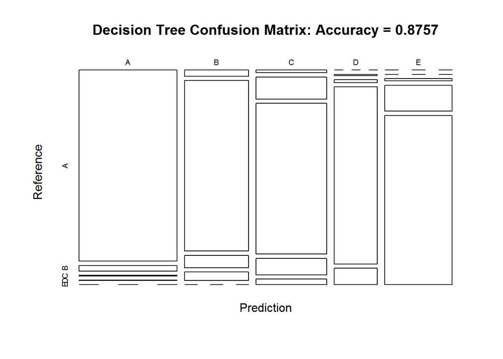

#Random Forext

```
## Confusion Matrix and Statistics
##
##           Reference
## Prediction    A    B    C    D    E
##          A 2232    0    0    0    0
##          B    0 1518    1    0    0
##          C    0    0 1367    8    0
##          D    0    0    0 1277    3
##          E    0    0    0    1 1439
##
## Overall Statistics
##
##                Accuracy : 0.9983
##                  95% CI : (0.9972, 0.9991)
##     No Information Rate : 0.2845
##     P-Value [Acc > NIR] : < 2.2e-16
##
##                   Kappa : 0.9979
##  Mcnemar's Test P-Value : NA
##
## Statistics by Class:
##
##                      Class: A Class: B Class: C Class: D Class: E
## Sensitivity            1.0000   1.0000   0.9993   0.9930   0.9979
## Specificity            1.0000   0.9998   0.9988   0.9995   0.9998
## Pos Pred Value         1.0000   0.9993   0.9942   0.9977   0.9993
## Neg Pred Value         1.0000   1.0000   0.9998   0.9986   0.9995
## Prevalence             0.2845   0.1935   0.1744   0.1639   0.1838
## Detection Rate         0.2845   0.1935   0.1742   0.1628   0.1834
## Detection Prevalence   0.2845   0.1936   0.1752   0.1631   0.1835
## Balanced Accuracy      1.0000   0.9999   0.9990   0.9963   0.9989
```

now lets look at the random forest accuracy

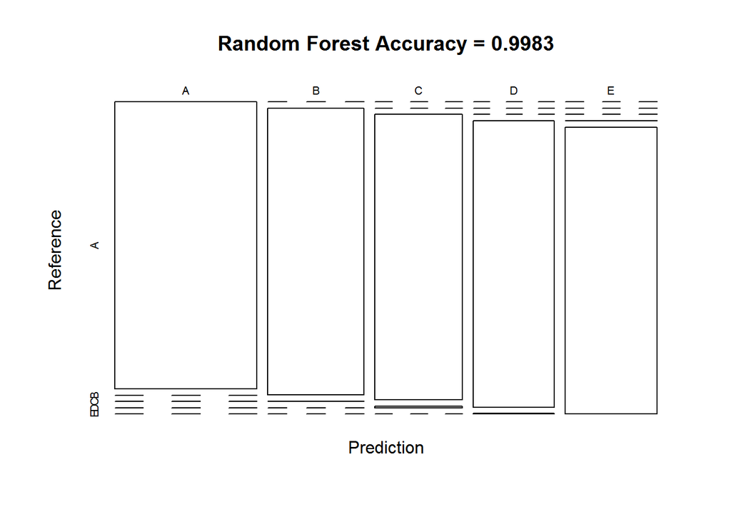

# Prediction with GBR

```r
set.seed(12543)
fitControl <- trainControl(method = "repeatedcv",
number = 5,repeats = 1)

gbmFit1 <- train(classe ~ ., data=myTraining, method = "gbm",
trControl = fitControl,verbose = FALSE)
gbmFinMod1 <- gbmFit1$finalModel

gbmPredTest <- predict(gbmFit1, newdata=myTesting)
gbmAccuracyTest <- confusionMatrix(gbmPredTest, myTesting$classe)
gbmAccuracyTest
```

```
## Confusion Matrix and Statistics
##
##           Reference
## Prediction    A    B    C    D    E
##          A 2231    0    0    0    0
##          B    1 1511    1    0    0
##          C    0    2 1365    4    0
##          D    0    5    2 1281    1
##          E    0    0    0    1 1441
##
## Overall Statistics
##
##                Accuracy : 0.9978
##                  95% CI : (0.9965, 0.9987)
##     No Information Rate : 0.2845
##     P-Value [Acc > NIR] : < 2.2e-16
##
##                   Kappa : 0.9973
##  Mcnemar's Test P-Value : NA
##
## Statistics by Class:
##
##                      Class: A Class: B Class: C Class: D Class: E
## Sensitivity            0.9996   0.9954   0.9978   0.9961   0.9993
## Specificity            1.0000   0.9997   0.9991   0.9988   0.9998
## Pos Pred Value         1.0000   0.9987   0.9956   0.9938   0.9993
## Neg Pred Value         0.9998   0.9989   0.9995   0.9992   0.9998
## Prevalence             0.2845   0.1935   0.1744   0.1639   0.1838
## Detection Rate         0.2843   0.1926   0.1740   0.1633   0.1837
## Detection Prevalence   0.2843   0.1928   0.1747   0.1643   0.1838
## Balanced Accuracy      0.9998   0.9975   0.9984   0.9974   0.9996
```

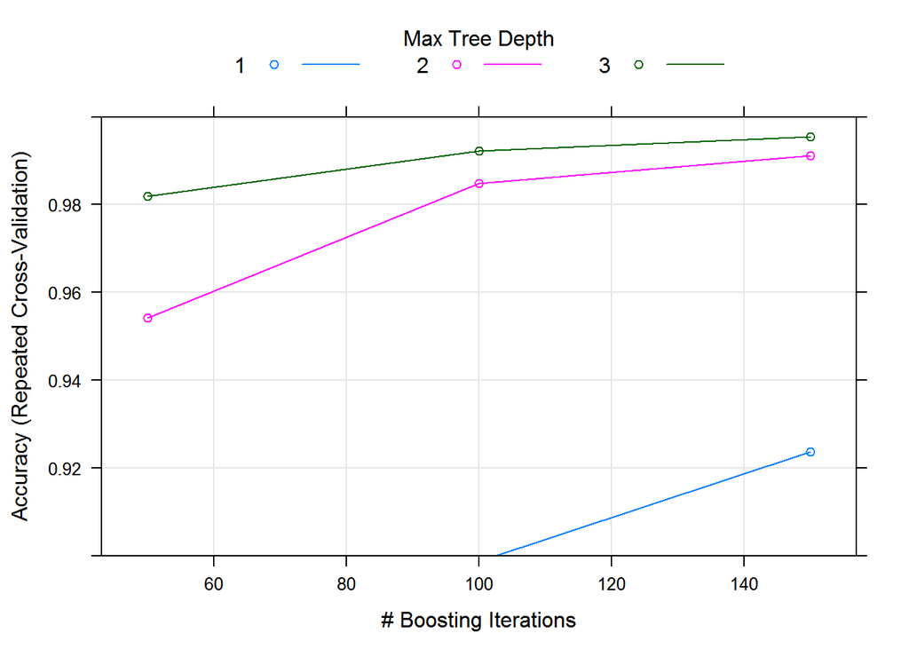